# Module 8 - Synthetic Control (Answer Key)

ECON 526/593E

# Synthetic Control

*Marijuana Medicalization and Motor Vehicle Fatalities: A Synthetic Control Group Approach*

**Click for Submission Instructions & Data**

Prepare your answers in R Markdown. Your submission should contain the exact same headings shown below along with your text and graphs, where appropriate, addressing all questions. When you knit your R Markdown script, use the following file naming convention for the html and Rmd documents you generate: lastname_module_N_homework.html (.Rmd) (replace "lastname" with your last name and "N" with the module number). Email your documents as attachments to ajc0056@mix.wvu.edu with the subject line "ECON 593 lastname Homework Module N". You can download the data for this module here. It will specify when/where packages are needed.

Synthetic control (SC) represents a powerful tool for the evaluation of economic policies. In the Mixtape, Scott Cunningham writes:

The estimator has been so influential that Athey and Imbens (2017a) said it was “arguably the most important innovation in the policy evaluation literature in the last 15 years” (p.3).

SC is a recently developed (2003) causal inference method. SC applies to a specific situation: (1) it requires panel data, typically where the cross-sectional unit is something like counties, metropolitan areas, states, or countries and (2) it requires that only one cross sectional unit is "treated" at a specific point in time. Despite this relatively specialized data requirement, many economic policy implementations exactly match these conditions. Since many students in this class will perform some sort of policy analysis as part of their jobs, SC is an important part of the applied economists' "toolkit." SC is also challenging to implement, in terms of the R coding involved. Because of this, the Module 8 homework will be very structured.

The homework is based on a paper by Bartos, Newark and McCleary (BNM) published in the *Journal of Experimental Criminology* that analyzes the impact of the legalization of marijuana for medicinal purposes in California in 1996 on fatal motor vehicle accidents. The key issue in this analysis, like all the previous causal inference examples covered in class, revolves around the comparison of the actual outcomes in California after the legalization of marijuana to the unobservable conterfactual or potential outcome that would have occurred in California if medical marijuana was not legalized. To estimate a causal effect, some observable proxy for counterfactual California post 1996 must be constructed.

Outcomes in other states likely represent poor proxies for counterfactual California, because the state is large and contains many people most living in densely inhabited urban areas. Using data from Montana or Utah as a proxy for conterfactual California would not be a good approach. Instead, SC constructs a "synthetic" California based on a weighted average of outcomes in all other states that did not legalize marijuana (the "donor pool"). The weights used are calculated in such a way that "synthetic" California closely matches outcomes in California in the pre-treatment period. Implementing SC requires the identification of one or more variables that will be used to match California to outcomes in other states.

## Question 1

Summarize the main research question in the BNM paper, the specific application analyzed, and why synthetic control is appropriate for this research question. Identify the outcome variable and the variables used for matching. (**2 Points**)

## Question 2

Implementing synthetic control in R requires two packages: `Synth` and `SCtools`. Install the packages `Synth` and `SCtools`. Read in the data, remove all observations before 1976, and generate summary statistics for the key variables. In your summary stats table, make sure to *only* display the sample size, mean, standard deviation, minimum and maximum. Describe what these data are, and why they are appropriate to answer the research question. (**2 points**)

```r
# install.packages("Synth")
library("Synth")

# install.packages("SCtools")
library("SCtools")

library("stargazer")
fars <- read.csv("https://alexcardazzi.github.io/teaching/econ-593e/fars_synth.csv", stringsAsFactors = FALSE)
fars <- fars[fars$year > 1975,]
stargazer(fars, type = "text",
          summary.stat = c("n", "mean", "sd"))
```

```
##
## =========================================================
## Statistic                 N       Mean        St. Dev.
## ---------------------------------------------------------
## state_id                2,040    26.000        14.723
## year                    2,040   1,995.500      11.546
## mv_deaths_perPerson     2,040    17.730         7.332
## mv_deaths_perPerson_lag 2,040    -0.288         1.963
## population              2,040 5,258,687.000 5,865,144.000
## population_per100k      2,040    52.587        58.651
## num_cars                1,989 2,508,156.000 2,778,403.000
## pop_15to19              1,938     0.077         0.011
## ---------------------------------------------------------
```

## Question 3

Describe the causal inference method used in BNM. Discuss the assumptions underlying the causal inference method used in the empirical analysis. Include a discussion of threats to validity of the results in terms of causal inference. (**2 points**)

## Question 4

In the paper, BNM mention that 37 states did *not* legalize marijuana through medical marijuana laws (MML) after California. The states that *did* pass MMLs after California are shown below. Following BNM, remove these states from the donor pool.

```r
bad_states <- c("Washington", "Oregon", "Alaska", "Maine", "Hawaii",
                "Colorado", "Nevada", "Maryland", "Vermont", "Montana",
                "Rhode Island", "New Mexico", "Dist of Columbia")
```

Plot a time series of annual traffic fatalities in California and the average number of annual traffic fatalities in the other non-MML states. Use the `aggregate()` function to help you. Place a dashed verical line at 1997, since this is when California's law passed. Make sure to include a legend and label the axes! (**2 points**)

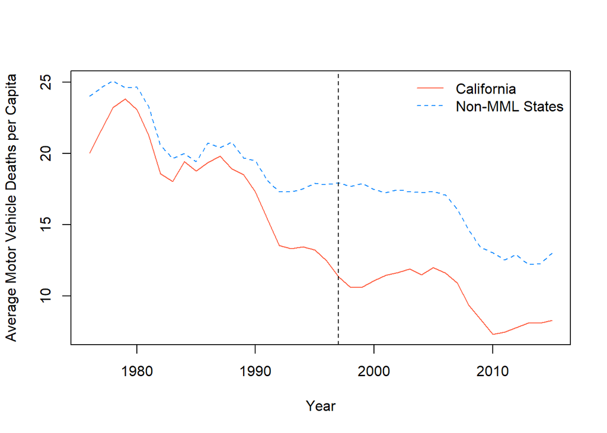

```r
lim <- !fars$state_name %in% bad_states

agg <- aggregate(fars$mv_deaths_perPerson[lim],
                 list(fars$year[lim], fars$state_name[lim] == "California"), mean)
plot(agg$Group.1, agg$x, type = "n",
     xlab = "Year", ylab = "Average Motor Vehicle Deaths per Capita",
     col = ifelse(agg$Group.2 == TRUE, "tomato", "dodgerblue"))
lines(agg$Group.1[agg$Group.2 == TRUE], agg$x[agg$Group.2 == TRUE], col = "tomato")
lines(agg$Group.1[agg$Group.2 == FALSE], agg$x[agg$Group.2 == FALSE], col = "dodgerblue", lty = 2)
abline(v = 1997, lty = 2)
legend("topright", legend = c("California", "Non-MML States"), col = c("tomato", "dodgerblue"), lty = 1:2, bty = "n")
```

## Question 5

Attempt to replicate the main results reported in BNM. Focus on Figure 2 as the main result. (**2 points**) Synthetic Control in R is a bit complicated to code. You should use the Mixtape chapter example for guidance!

The data require some pre-processing before SC can be implemented. Recall that SC first matches control units in the donor pool to the treated unit in the pre-treatment period using observable variables (covariates). The Mixtape discusses matching covariate selection in this section:

https://mixtape.scunning.com/synthetic-control.html#picking-synthetic-controls

The key idea is that these covariates are used to estimate the weights applied to the outcome variable in the donor pool to construct a "synthetic" counterfactual state outcome. In the Mixtape SC example on prison construction in Texas and black male incarceration (https://mixtape.scunning.com/synthetic-control.html#prison-construction-and-black-male-incarceration), the SC weights used to construct "synthetic Texas" are 40.8% for California, 36% for Illinois, 12.2% for Louisiana, and 10.9% for Florida.

Although SC is supposed to remove researcher-related bias from the analysis by optimally determining the weights through a statistical approach, the actual implementation of SC is more complicated because the researcher must select the covariates used for matching. There is no guidance on how to select covariates for matching. In the Mixtape Texas prison example, Cunningham uses a variety of variables measured at different points in the pre-treatment period, including alcohol sales, AIDS infection rates, and the fraction of the state population between 15 and 19 (see his R code synth_1.r for the exact variables).

Again, matching covariate selection is entirely up to the researcher. BNM make a curious choice for their matching covariates. BNMs outcome variable is the number of fatal vehicle crashes per 100,000 population in a state. BNM calculate the year-to-year change in this variable in each state (`mv_deaths_perPerson_lag`).That is the only "covariate" BNM match on. They do not use any other observable variables to match California to other states in the donor pool and construct the SC weights. Note that BNM do not list their matching covariates anywhere in the paper. They only show the weights estimated from their matching in Appendix 2, Table 3. The only way to find out what matching covariates were used by BNM is to look at the code they provided at the journal web site.

To match BNM, use the following code for data pre-processing prior to implementing SC:

```r
dataprep.out <- dataprep(
  foo = fars,
  predictors = c("mv_deaths_perPerson", "mv_deaths_perPerson_lag"),

  predictors.op = "mean",
  time.predictors.prior = 1976:1996,

  dependent = "mv_deaths_perPerson",
  unit.variable = "state_id",
  unit.names.variable = "state_name",
  time.variable = "year",
  treatment.identifier = 5,
  controls.identifier = unique(fars$state_id[lim & fars$state_name != "California"]),
  time.optimize.ssr = 1976:1996,
  time.plot = 1976:2015
)
```

- Step 1: Generate the synthetic control plot using the package `synth`. Draw a vertical dashed line at 1997.

```
##
## X1, X0, Z1, Z0 all come directly from dataprep object.
##
##
## ****************
##  searching for synthetic control unit
##
##
## ****************
## ****************
## ****************
##
## MSPE (LOSS V): 1.385394
##
## solution.v:
##  0.02940493 0.9705951
##
## solution.w:
##  0.01878181 0.01985626 0.01952663 0.01876737 0.01959092 0.01980833 0.01982064 0.01967144 0.01708862 0.01965827 0.01867089 0.01978047 0.01976983 0.01976584 0.3192821 0.01947423 0.0162214 0.01930617 0.01959257 0.01905744 0.01712896 0.0173291 0.01580356 0.0196895 0.0009979244 0.01915386 0.01975456 0…
```

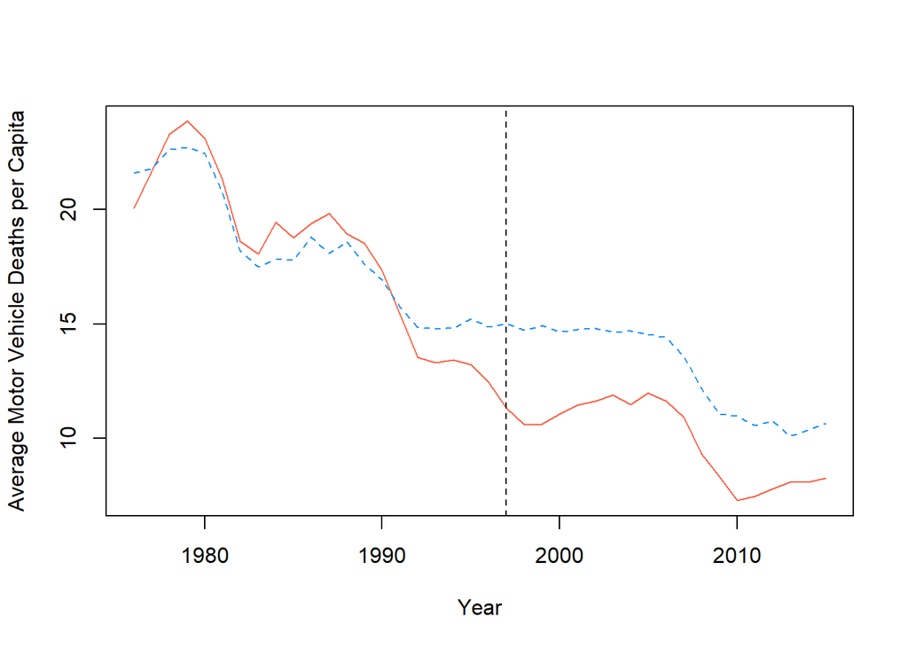

```r
synth.out <- synth(data.prep.obj = dataprep.out)

plot(1976:2015, dataprep.out$Y1plot, lty = 1, type = "l", col = "tomato",
     xlab = "Year", ylab = "Average Motor Vehicle Deaths per Capita")
lines(1976:2015,dataprep.out$Y0plot %*% synth.out$solution.w, col = "dodgerblue", lty = 2)
abline(v = 1997, lty = 2)
```

Again, the difference between California and "synthetic California" is an estimate of the causal impact of MML laws on traffic fatalities. These graphs are widely viewed as the primary evidence that SC works. Compare this graph to the one from Question 4.

- Step 2: Display the weights for the top 5 donor pool states that contribute to "synthetic California." Compare these to the results in BNM's Appendix 2, Table 3.

```r
synth.tables <- synth.tab(dataprep.res = dataprep.out, synth.res = synth.out)
tbl <- synth.tables$tab.w
tbl[order(-tbl$w.weights)[1:5],]
```

```
##    w.weights    unit.names unit.numbers
## 22     0.319 Massachusetts           22
## 51     0.034       Wyoming           51
## 3      0.020       Arizona            3
## 4      0.020      Arkansas            4
## 8      0.020      Delaware            8
```

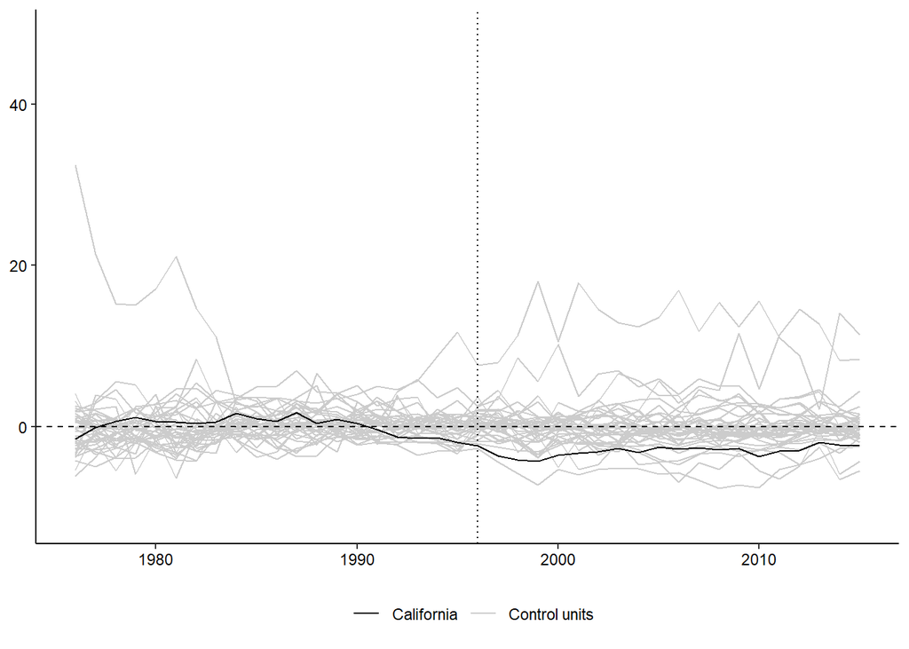

```r
plot_placebos(placebos)
```

Explain what you learn from this graph.

- Step 4: BNM make an unusual choice in terms of matching covariates: they do not include any variables unrelated to the outcome variable. Does this drive their results? One way to assess this is to estimate an alternative SC model that uses other matching covariates. Re-estimate the SC model including two additional variables from the data file, or functions of variables in the data file, as SC matching covariates. Generate the SC plot for this alternative model. You do not need to redo the placebo test, but you do need to display the weights.

```
##
## X1, X0, Z1, Z0 all come directly from dataprep object.
##
##
## ****************
##  searching for synthetic control unit
##
##
## ****************
## ****************
## ****************
##
## MSPE (LOSS V): 0.5702429
##
## solution.v:
##  0.1088846 0.2718411 0.003680107 0.6155942
##
## solution.w:
##  0.002752405 0.12084 1.22283e-05 0.003176735 0.005748825 0.2439444 0.00425333 0.004259164 0.006230933 0.004482517 0.004794632 0.007991069 0.004298233 0.002195899 0.2441406 0.003948107 0.005659809 0.0002712122 0.006561077 0.007447388 0.004439193 0.001546231 0.2140539 0.006310102 0.004436984 0.0046…
```

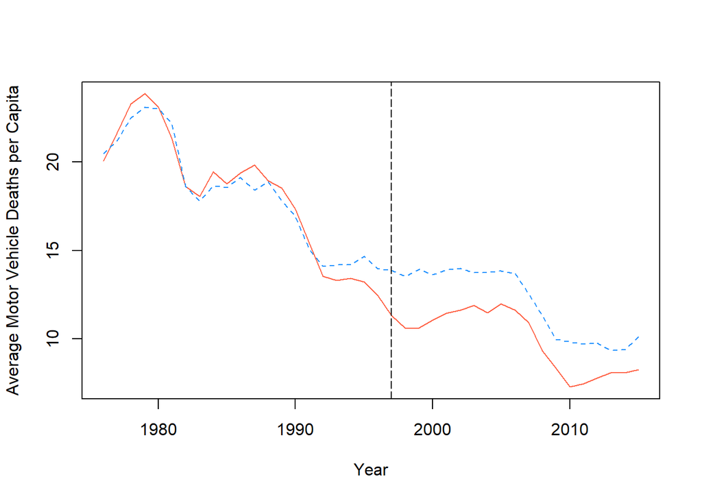

```r
fars$car_perPerson <- fars$num_cars / fars$population
dataprep.out <- dataprep(
  foo = fars,
  predictors = c("mv_deaths_perPerson", "mv_deaths_perPerson_lag", "car_perPerson", "pop_15to19"),

  predictors.op = "mean",
  time.predictors.prior = 1976:1996,

  dependent = "mv_deaths_perPerson",
  unit.variable = "state_id",
  unit.names.variable = "state_name",
  time.variable = "year",
  treatment.identifier = 5,
  controls.identifier = unique(fars$state_id[lim & fars$state_name != "California"]),
  time.optimize.ssr = 1976:1996,
  time.plot = 1976:2015
)

synth.out <- synth(data.prep.obj = dataprep.out)

plot(1976:2015, dataprep.out$Y1plot, lty = 1, type = "l", col = "tomato",
     xlab = "Year", ylab = "Average Motor Vehicle Deaths per Capita")
lines(1976:2015, dataprep.out$Y0plot %*% synth.out$solution.w, col = "dodgerblue", lty = 2)
abline(v = 1997, lty = 1997)
```

```r
synth.tables <- synth.tab(dataprep.res = dataprep.out, synth.res = synth.out)
tbl <- synth.tables$tab.w
tbl[order(-tbl$w.weights)[1:5],]
```

```
##    w.weights    unit.names unit.numbers
## 10     0.244       Florida           10
## 22     0.244 Massachusetts           22
## 33     0.214      New York           33
## 3      0.121       Arizona            3
## 51     0.024       Wyoming           51
```

Compare this graph to the one from step 1 above.

## Question 6

Discuss the results you generate. (2 points)

- Step 1: What are your thoughts on the synthetic control method?
- Step 2: Do you believe the states identified by the SC weights are good comparisons for California?
- Step 3: What do you think about the placebo test?
- Step 4: What variables did you choose for the matching covariates and why? Did this generate a "better" or "worse" synthetic version of California than BNM? Are your weights better or worse than BNM's?

## Question 7

Compare your results and this application to the example in the Mixtape chapter for SC (Texas prisions and black male incarceration). Is this application better or worse than the one in the Mixtape? How does this application, and these results, differ? For example, strength of assumptions, effect size, etc. (2 points)

## Question 8

Do you believe the result in BNM is credibly causal? Are the sign and magnitude plausible? (2 points)

## Bonus Bonus

How could you improve the analysis of MMLs and traffic fatalities? (Hint: think about the states removed from the sample in Question 4) How could you answer this research question using a different causal inference method? Give it a try!

```r
bad_states <- c("California", bad_states)
bad_dates <- c(1997, 1999, 1999, 1999, 2000, 2001, 2001, 2002, 2004, 2005, 2005, 2007, 2008, 2009, 2011, 2011, 2011, 2012, 2013, 2014, 2013, 2014, 2015, 2015)

fars$treat_time <- bad_dates[match(fars$state_name, bad_states)]
fars$treat_time <- ifelse(is.na(fars$treat_time), 2016, fars$treat_time)

fars$DiD <- ifelse(fars$treat_time <= fars$year, 1, 0)

reg1 <- lm(mv_deaths_perPerson ~ DiD + as.factor(state_name) + as.factor(year), data = fars)
reg2 <- lm(mv_deaths_perPerson ~ DiD + as.factor(state_name) + as.factor(year) + pop_15to19 + car_perPerson, data = fars)
stargazer(reg1, reg2, omit = c("factor"), type = "text")
```

```
##
## =========================================================================
##                                      Dependent variable:
##                     -----------------------------------------------------
##                                      mv_deaths_perPerson
##                                (1)                        (2)
## -------------------------------------------------------------------------
## DiD                         -2.240***                  -1.984***
##                              (0.287)                    (0.302)
##
## pop_15to19                                               -0.268
##                                                         (18.137)
##
## car_perPerson                                          14.574***
##                                                         (1.527)
##
## Constant                    29.965***                  22.488***
##                              (0.584)                    (2.149)
##
## -------------------------------------------------------------------------
## Observations                  2,040                      1,938
## R2                            0.863                      0.866
## Adjusted R2                   0.857                      0.860
## Residual Std. Error     2.776 (df = 1949)          2.739 (df = 1847)
## F Statistic         136.356*** (df = 90; 1949) 132.907*** (df = 90; 1847)
## =========================================================================
## Note:                                         *p<0.1; **p<0.05; ***p<0.01
```